# Test a Perceptual Phenomenon

### - Investigation of the Stroop Effect

### Author: Jiayi Liao

#### Backgound Information

In a Stroop task, participants are presented with a list of words, with each word displayed in a color of ink. The participant’s task is to say out loud the color of the ink in which the word is printed. The task has two conditions: a congruent words condition, and an incongruent words condition. In the congruent words condition, the words being displayed are color words whose names match the colors in which they are printed: for example RED, BLUE. In the incongruent words condition, the words displayed are color words whose names do not match the colors in which they are printed: for example PURPLE, ORANGE. In each case, we measure the time it takes to name the ink colors in equally-sized lists. Each participant will go through and record a time from each condition. (Reference: https://docs.google.com/document/d/1-OkpZLjG_kX9J6LIQ5IltsqMzVWjh36QpnP2RYpVdPU/pub?embedded=True)

[figure not shown]

#### My test results:

Congruent words: 10.482s

Incongruent words: 12.595s

## 1. What is our independent variable? What is our dependent variable?

Independent Variable: Congruency between the words and the color of the words shown on the test, one being a congruent words and color condition, the other being an incongruent words and color condition.

Dependent Variable: The time it takes the same participant to name the ink colors under congruency and incongruency.

## 2. What is an appropriate set of hypotheses for this task? What kind of statistical test do you expect to perform? Justify your choices.

It took me longer to read texts in the incongruent group and the hypothesis will be based on my experience.

#### Null Hypothesis:

H0:μdiff=0 -Saying the ink color of the text when color differs from the text takes the same time as saying it when the text and the color matches.

In the dataset there is results of 24 participants, each participant went through and timed from congruent words condition and incongruent words condition. To analyze the paired data, t-test will be used due to the small sample size (n<30). If the sample size is more than 30, z-score can be used instead of t-test. The analysis meansures the difference of each pair of record to test for any significant differences in terms of time.

## 3. Report some descriptive statistics regarding this dataset. Include at least one measure of central tendency and at least one measure of variability.

```python
#import libraries
import math
import pandas as pd
import numpy as np
import seaborn as sns
import matplotlib.pyplot as plt
from scipy.stats import t
%matplotlib inline
```

```python
import pandas as pd
df = pd.read_csv('./stroopdata.csv') #load the data
```

```python
df.describe() #overall statistics of the data set
```

|  | Congruent | Incongruent |
| --- | --- | --- |
| count | 24.000000 | 24.000000 |
| mean | 14.051125 | 22.015917 |
| std | 3.559358 | 4.797057 |
| min | 8.630000 | 15.687000 |
| 25% | 11.895250 | 18.716750 |
| 50% | 14.356500 | 21.017500 |
| 75% | 16.200750 | 24.051500 |
| max | 22.328000 | 35.255000 |

```python
df.head() #preview of the data
```

|  | Congruent | Incongruent |
| --- | --- | --- |
| 0 | 12.079 | 19.278 |
| 1 | 16.791 | 18.741 |
| 2 | 9.564 | 21.214 |
| 3 | 8.630 | 15.687 |
| 4 | 14.669 | 22.803 |

## 4. Provide one or two visualizations that show the distribution of the sample data. Write one or two sentences noting what you observe about the plot or plots.

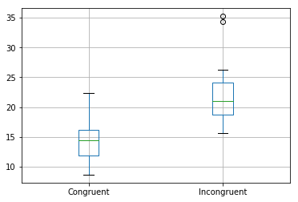

```python
df.boxplot(); #distribution of the 2 groups
```

Congruent group median is around 14.5 and the median in the incongruent group is around 21. The interquartile range of the congruent group is lower.

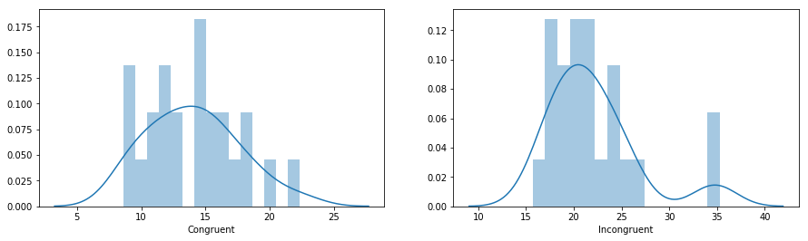

```python
fig = plt.figure(figsize=(15,4))
ax1 = fig.add_subplot(121)
sns.distplot(df.Congruent, ax=ax1, bins=15) #plot Congruent group in histogram with distribution curve

ax2 = fig.add_subplot(122)
_=sns.distplot(df.Incongruent, ax=ax2, bins=15) #plot Incongruent group in histogram with distribution curve
```

## 5. Now, perform the statistical test and report your results. What is your confidence level and your critical statistic value? Do you reject the null hypothesis or fail to reject it? Come to a conclusion in terms of the experiment task. Did the results match up with your expectations?

Statistical test:

- α = .05 (confidence level at 95%)
- degrees of freedom = n-1=23

```python
t.ppf(.95, 23) # Get the t-critical value for a 95% confidence level and 23 degrees of freedom
```

```
1.7138715277470473
```

T-critical value is at 1.71 with a confidence level of 95% and 23 degrees of freedom.

```python
mean_diff =df.Incongruent.mean()-df.Congruent.mean()
print (mean_diff) #calculate difference of the means from the 2 groups.
```

```
7.964791666666665
```

Difference of the mean is 7.96

```python
df['Difference'] = df['Congruent'] - df['Incongruent']
df['Difference'].std(axis=0) #standard deviation of the differences.
```

```
4.864826910359056
```

```python
7.96/(4.86 / math.sqrt(24)) #t-statistic
```

```
8.023842943437899
```

### Conclusion

Reject null hypothesis because t-statistic (8.02) is greater than the critical value (1.71). Hypothesis matches with expectation.